# Milestone - Music Recommendation Systems - Final

## Milestone Submission - Music Recommendation System

### Music streaming platforms need to surface relevant songs from large catalogs to retain users. This project builds a recommendation system on the Million Song Dataset to predict what songs a user is likely to listen to based on past play counts.

## In this exercise, the objective is to build and evaluate recommendation systems that better predict the interaction between users and songs. The process will follow these steps:

```
Exploratory Data Analysis (EDA): Explore and visualize the data to uncover patterns, distributions, and key statistics that inform the modeling approach.

Data Quality & Preprocessing: Identify and address any anomalies, missing values, or inconsistencies to ensure the data is clean and reliable.

Building Recommendation Systems: Develop multiple recommendation models using different techniques — including popularity-based, collaborative filtering, matrix factorization, and content-based approaches.

Model Evaluation: Test and compare the performance of each model using appropriate metrics such as Precision@K, Recall@K, F1 Score, and RMSE.

Conclusions & Recommendations: Based on model performance, draw conclusions on the most effective approach and provide recommendations on model selection, as well as any improvements to data collection or processing that could further enhance prediction quality.
```

## Loading the necessary libraries

```python
import warnings
import pandas as pd
import numpy as np
import seaborn as sns
import matplotlib.pyplot as plt
from collections import defaultdict
from sklearn.metrics import mean_squared_error
import gdown

import warnings
warnings.filterwarnings('ignore')
```

### Loading the dataset using gdown library

```python
gdown.download("https://drive.google.com/drive/folders/1ODwlvrIwPPIYnwJcAu8K0ALYNMOZM2C9?usp=sharing", "count_data.csv", quiet = False)
```

```
Downloading...
From: https://drive.google.com/drive/folders/1ODwlvrIwPPIYnwJcAu8K0ALYNMOZM2C9?usp=sharing
To: C:\Users\aae2082\count_data.csv
1.36MB [00:00, 3.14MB/s]
```

```
'count_data.csv'
```

```python
gdown.download_folder(
    "https://drive.google.com/drive/folders/1ODwlvrIwPPIYnwJcAu8K0ALYNMOZM2C9?usp=sharing",
    quiet=False,
    use_cookies=False
)
```

```
Retrieving folder contents
```

```
Processing file 1G-Z7sACzbH1ziI2nYuGMjoEttGFqsnbW count_data.csv
Processing file 1hW3UUQjKwMH_THHh3mn_UAoG-gM2Ay-Z song_data.csv
```

```
Retrieving folder contents completed
Building directory structure
Building directory structure completed
Downloading...
From (original): https://drive.google.com/uc?id=1G-Z7sACzbH1ziI2nYuGMjoEttGFqsnbW
From (redirected): https://drive.google.com/uc?id=1G-Z7sACzbH1ziI2nYuGMjoEttGFqsnbW&confirm=t&uuid=530b0efd-2874-4de5-a589-8bab97db882a
To: C:\Users\aae2082\Million Songs Dataset\count_data.csv
Downloading...
From: https://drive.google.com/uc?id=1hW3UUQjKwMH_THHh3mn_UAoG-gM2Ay-Z
To: C:\Users\aae2082\Million Songs Dataset\song_data.csv
Download completed
```

```
['C:\\Users\\aae2082\\Million Songs Dataset\\count_data.csv',
 'C:\\Users\\aae2082\\Million Songs Dataset\\song_data.csv']
```

```python
count_df = pd.read_csv("Million Songs Dataset/count_data.csv", index_col=0)
count_df.head()
```

|  | user_id | song_id | play_count |
| --- | --- | --- | --- |
| 0 | b80344d063b5ccb3212f76538f3d9e43d87dca9e | SOAKIMP12A8C130995 | 1 |
| 1 | b80344d063b5ccb3212f76538f3d9e43d87dca9e | SOBBMDR12A8C13253B | 2 |
| 2 | b80344d063b5ccb3212f76538f3d9e43d87dca9e | SOBXHDL12A81C204C0 | 1 |
| 3 | b80344d063b5ccb3212f76538f3d9e43d87dca9e | SOBYHAJ12A6701BF1D | 1 |
| 4 | b80344d063b5ccb3212f76538f3d9e43d87dca9e | SODACBL12A8C13C273 | 1 |

```python
song_df = pd.read_csv("Million Songs Dataset/song_data.csv")
song_df.head()
```

|  | song_id | title | release | artist_name | year |
| --- | --- | --- | --- | --- | --- |
| 0 | SOQMMHC12AB0180CB8 | Silent Night | Monster Ballads X-Mas | Faster Pussy cat | 2003 |
| 1 | SOVFVAK12A8C1350D9 | Tanssi vaan | Karkuteillä | Karkkiautomaatti | 1995 |
| 2 | SOGTUKN12AB017F4F1 | No One Could Ever | Butter | Hudson Mohawke | 2006 |
| 3 | SOBNYVR12A8C13558C | Si Vos Querés | De Culo | Yerba Brava | 2003 |
| 4 | SOHSBXH12A8C13B0DF | Tangle Of Aspens | Rene Ablaze Presents Winter Sessions | Der Mystic | 0 |

Now we have two seperate datasets - the goal is join them using song id as a joiner, so we can have the necessary fields (user id, song id, and the play count in one dataset)

### Merging the two datasets and dropping the unecessary fields

```python
df = pd.merge(count_df, song_df.drop_duplicates(['song_id']), on="song_id", how="left")
df.head()
```

|  | user_id | song_id | play_count | title | release | artist_name | year |
| --- | --- | --- | --- | --- | --- | --- | --- |
| 0 | b80344d063b5ccb3212f76538f3d9e43d87dca9e | SOAKIMP12A8C130995 | 1 | The Cove | Thicker Than Water | Jack Johnson | 0 |
| 1 | b80344d063b5ccb3212f76538f3d9e43d87dca9e | SOBBMDR12A8C13253B | 2 | Entre Dos Aguas | Flamenco Para Niños | Paco De Lucia | 1976 |
| 2 | b80344d063b5ccb3212f76538f3d9e43d87dca9e | SOBXHDL12A81C204C0 | 1 | Stronger | Graduation | Kanye West | 2007 |
| 3 | b80344d063b5ccb3212f76538f3d9e43d87dca9e | SOBYHAJ12A6701BF1D | 1 | Constellations | In Between Dreams | Jack Johnson | 2005 |
| 4 | b80344d063b5ccb3212f76538f3d9e43d87dca9e | SODACBL12A8C13C273 | 1 | Learn To Fly | There Is Nothing Left To Lose | Foo Fighters | 1999 |

```python
df_test = pd.merge(count_df, song_df.drop_duplicates(['song_id']), on="song_id", how="left")
df_test.head()
```

|  | user_id | song_id | play_count | title | release | artist_name | year |
| --- | --- | --- | --- | --- | --- | --- | --- |
| 0 | b80344d063b5ccb3212f76538f3d9e43d87dca9e | SOAKIMP12A8C130995 | 1 | The Cove | Thicker Than Water | Jack Johnson | 0 |
| 1 | b80344d063b5ccb3212f76538f3d9e43d87dca9e | SOBBMDR12A8C13253B | 2 | Entre Dos Aguas | Flamenco Para Niños | Paco De Lucia | 1976 |
| 2 | b80344d063b5ccb3212f76538f3d9e43d87dca9e | SOBXHDL12A81C204C0 | 1 | Stronger | Graduation | Kanye West | 2007 |
| 3 | b80344d063b5ccb3212f76538f3d9e43d87dca9e | SOBYHAJ12A6701BF1D | 1 | Constellations | In Between Dreams | Jack Johnson | 2005 |
| 4 | b80344d063b5ccb3212f76538f3d9e43d87dca9e | SODACBL12A8C13C273 | 1 | Learn To Fly | There Is Nothing Left To Lose | Foo Fighters | 1999 |

Created a test data to validate the popular songs against artist names, release and year. This wont be used in the recommendation models

Next - i will drop the unneccessary fields so we can build a clean model without factoring in fields that wont be used.

```python
df = df.drop(['title','release','artist_name','year'], axis = 1)
```

```python
df.head()
```

|  | user_id | song_id | play_count |
| --- | --- | --- | --- |
| 0 | b80344d063b5ccb3212f76538f3d9e43d87dca9e | SOAKIMP12A8C130995 | 1 |
| 1 | b80344d063b5ccb3212f76538f3d9e43d87dca9e | SOBBMDR12A8C13253B | 2 |
| 2 | b80344d063b5ccb3212f76538f3d9e43d87dca9e | SOBXHDL12A81C204C0 | 1 |
| 3 | b80344d063b5ccb3212f76538f3d9e43d87dca9e | SOBYHAJ12A6701BF1D | 1 |
| 4 | b80344d063b5ccb3212f76538f3d9e43d87dca9e | SODACBL12A8C13C273 | 1 |

### For purposes of the recommendation system, we will convert user id and song id to numeric features using the labelEncoder library

```python
from sklearn.preprocessing import LabelEncoder

le_user = LabelEncoder()
le_song = LabelEncoder()

df['user_id'] = le_user.fit_transform(df['user_id'])
df['song_id'] = le_song.fit_transform(df['song_id'])
```

## Exploring the dataset and performing EDA

```python
user_counts = df['user_id'].value_counts().to_dict()

#using list comprehension to create the cutoff

USER_CUTOFF = 90
remove_users = [user for user, count in user_counts.items() if count < USER_CUTOFF]
df = df.loc[~df['user_id'].isin(remove_users)]

# ── 2. Filter Songs ──────────────────────────────────────────
song_counts = df['song_id'].value_counts().to_dict()

SONG_CUTOFF = 120
remove_songs = [song for song, count in song_counts.items() if count < SONG_CUTOFF]
df_final = df.loc[~df['song_id'].isin(remove_songs)]

df_final = df_final[df_final['play_count'] <= 5]
```

```python
df_final
df = df_final
```

```python
print("=== Info ====")
print(df.info())

print("=== shape ====")
print(df.shape)

print("=== Missing Values ===")
print(df.isnull().sum())

print("=== Duplicates ===")
print(df.duplicated().sum())
```

```
=== Info ====
<class 'pandas.core.frame.DataFrame'>
Index: 117876 entries, 200 to 1999765
Data columns (total 3 columns):
 #   Column      Non-Null Count   Dtype
---  ------      --------------   -----
 0   user_id     117876 non-null  int32
 1   song_id     117876 non-null  int32
 2   play_count  117876 non-null  int64
dtypes: int32(2), int64(1)
memory usage: 2.7 MB
None
=== shape ====
(117876, 3)
=== Missing Values ===
user_id       0
song_id       0
play_count    0
dtype: int64
=== Duplicates ===
0
```

After refinement of the dataset, the dataset contains 117,876 observations. The strategy is to keep as many observations as we can to make an efficeint and scalable models. so i ll start with keeping the observations intact without any other cutoffs

The data contains 3 int - data type fields and encoding the fields to numeric features

Good thing we dont have any missing values or duplicates

```python
df['play_count'].describe()
```

```
count    117876.000000
mean          1.700058
std           1.089517
min           1.000000
25%           1.000000
50%           1.000000
75%           2.000000
max           5.000000
Name: play_count, dtype: float64
```

after applying the play_count ≤ 5 filter

```python
df.head()
```

|  | user_id | song_id | play_count |
| --- | --- | --- | --- |
| 200 | 6958 | 447 | 1 |
| 202 | 6958 | 512 | 1 |
| 203 | 6958 | 549 | 1 |
| 204 | 6958 | 703 | 1 |
| 205 | 6958 | 719 | 1 |

```python
print(df['user_id'].nunique())
print(df['song_id'].nunique())
```

```
3155
563
```

There are 3,155 unique users and 563 unique songs, resulting in 1.8M possible user-song interactions. However, only 117,876 interactions are observed. We will use play_count as the interaction signal to identify similarity between users and song preferences to build the recommendation models.

## Quick Data Validation

```python
df.groupby(['user_id', 'song_id']).count()
```

| user_id | song_id | play_count |
| --- | --- | --- |
| 11 | 5158 | 1 |
|  | 8019 | 1 |
|  | 8882 | 1 |
| 17 | 314 | 1 |
|  | 703 | 1 |
| ... | ... | ... |
| 76342 | 5375 | 1 |
|  | 7889 | 1 |
|  | 8494 | 1 |
|  | 9942 | 1 |
| 76347 | 5879 | 1 |

117876 rows × 1 columns

```python
df.groupby(['user_id', 'song_id']).count()['play_count'].sum()
```

```
117876
```

the sum is equal to the total number of observations, which states that there is only one interaction between a pair of a song and a user "117,876"

```python
df['user_id'].value_counts()
```

```
user_id
61472    243
15733    227
37049    202
9570     184
23337    177
        ...
19776      1
45476      1
17961      1
14439      1
10412      1
Name: count, Length: 3155, dtype: int64
```

user "61472" has the most song interactions "243"

```python
df['song_id'].value_counts()
```

```
song_id
8582    751
352     748
2220    713
1118    662
4152    652
       ...
9048    103
6450    102
990     101
4831     97
8324     96
Name: count, Length: 563, dtype: int64
```

Song id "8582" has the most user interactions with "751"

```python
print(df['song_id'].value_counts().sum())
print(df['play_count'].sum())
print(df.groupby('song_id')['play_count'].sum())
```

```
117876
200396
song_id
21      430
22      197
52      728
62      197
93      167
       ...
9939    389
9942    373
9960    222
9981    292
9989    160
Name: play_count, Length: 563, dtype: int64
```

```python
print(df['play_count'].value_counts().sort_index())
```

```
play_count
1    72473
2    23890
3    10774
4     5874
5     4865
Name: count, dtype: int64
```

```python
Count_Interactions = df.groupby('user_id').count()['song_id']
Count_Interactions
```

```
user_id
11        3
17       34
57       24
84       42
120       7
         ..
76300    37
76307    21
76331    19
76342     8
76347     1
Name: song_id, Length: 3155, dtype: int64
```

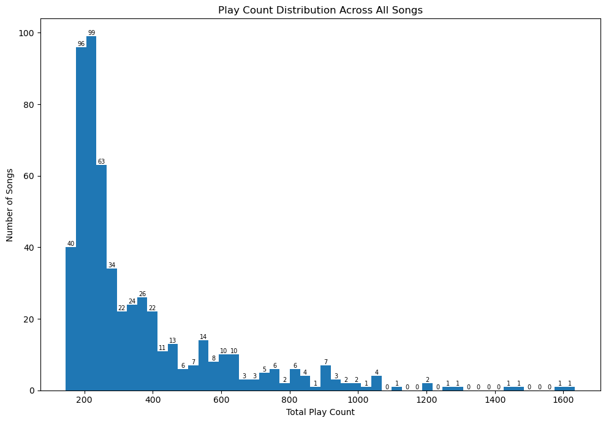

```python
# 1. Play count distribution across ALL songs
fig, ax = plt.subplots(figsize=(10,7))
counts, bins, patches = ax.hist(df.groupby('song_id')['play_count'].sum(), bins=50)
ax.bar_label(ax.containers[0], fmt='%d', label_type='edge', fontsize=7)
ax.set_xlabel('Total Play Count')
ax.set_ylabel('Number of Songs')
ax.set_title('Play Count Distribution Across All Songs')
plt.tight_layout()
plt.show()
```

the vast majority of songs cluster in the low play count range, while only a handful of songs accumulate very high total plays. This confirms that a small number of popular songs dominate listening activity, which directly motivates the rank-based recommendation model for now.

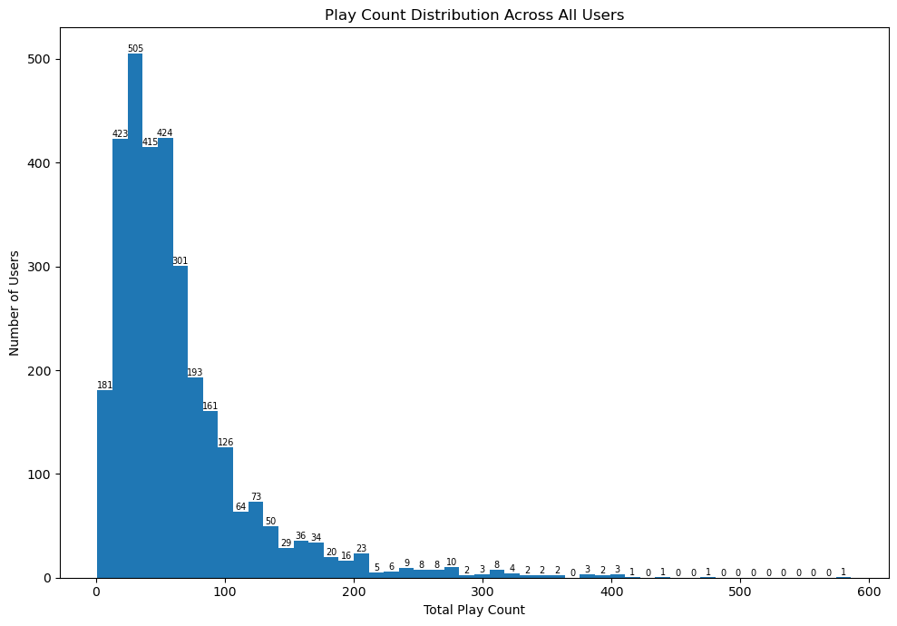

```python
fig, ax = plt.subplots(figsize=(10,7))
counts, bins, patches = ax.hist(df.groupby('user_id')['play_count'].sum(), bins=50)
ax.bar_label(ax.containers[0], fmt='%d', label_type='edge', fontsize=7)
ax.set_xlabel('Total Play Count')
ax.set_ylabel('Number of Users')
ax.set_title('Play Count Distribution Across All Users')
plt.tight_layout()
plt.show()
```

Again the distribution is heavily right-skewed, with most users having a relatively low total play count and a small group of highly active users far exceeding the average. This reinforces the "power user" pattern observed in the value counts earlier.

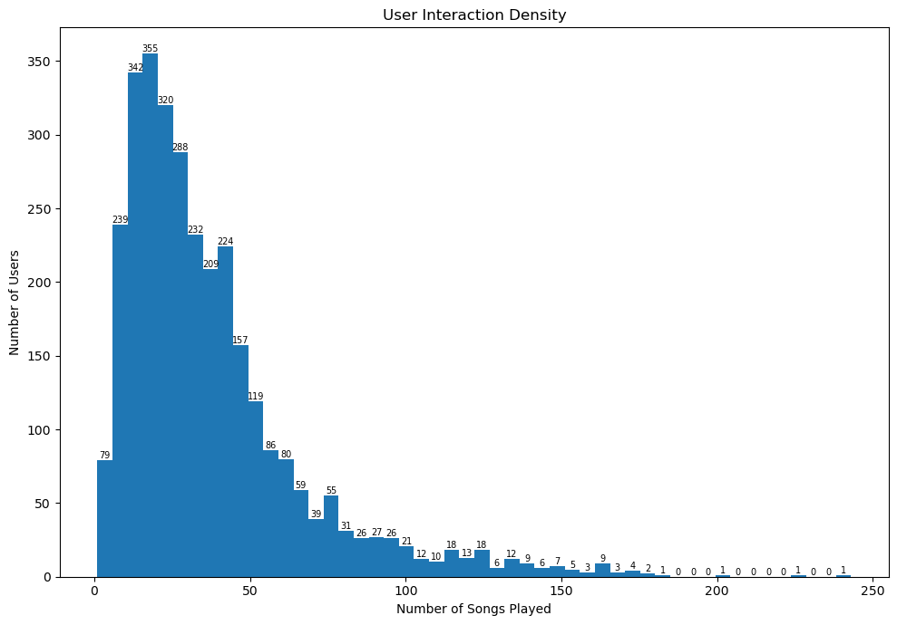

```python
# 3. Number of songs per user (interaction density)
fig, ax = plt.subplots(figsize=(10,7))
counts, bins, patches = ax.hist(df.groupby('user_id')['song_id'].count(), bins=50)
ax.bar_label(ax.containers[0], fmt='%d', label_type='edge', fontsize=7)
ax.set_xlabel('Number of Songs Played')
ax.set_ylabel('Number of Users')
ax.set_title('User Interaction Density')
plt.tight_layout()
plt.show()
```

this one is closer to a right-skewed bell shape — most users have interacted with somewhere between 10 and 100 songs, with the peak around 10–40 songs. Very few users sit at the extremes of 1 song or 200+ songs. This moderate density is an encouraging sign for collaborative filtering, as most users have enough interaction history to compute meaningful similarity scores.

### Before diving into the recommendation systems techniques lets do an artist analysis and Year analysis

```python
print(f"Unique artists: {df_test['artist_name'].nunique()}")
print("\nTop 10 most interacted artists:")
df_test[df_test['user_id'].isin(le_user.inverse_transform(df['user_id'].unique()))]\
    .groupby('artist_name')['play_count'].sum()\
    .sort_values(ascending=False).head(10)
```

```
Unique artists: 3375

Top 10 most interacted artists:
```

```
artist_name
Coldplay                  17595
The Black Keys            14153
Kings Of Leon             11874
Florence + The Machine    11835
Jack Johnson              10684
The Killers               10481
Radiohead                  8637
Muse                       8430
Daft Punk                  7760
Gorillaz                   7144
Name: play_count, dtype: int64
```

There are around 3375 unique artists, of course, Coldplay is ubiquitously known, so they have the most listened songs, we can see kings of leon and daft punk in the top 10 which is relevant, they are hugely famous

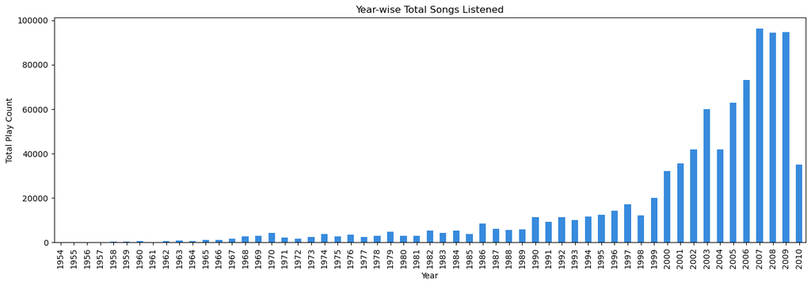

```
Year with most plays: 2007 with 96391 total plays
```

```python
year_listens = df_test[
    (df_test['year'] > 0) &
    (df_test['user_id'].isin(le_user.inverse_transform(df['user_id'].unique())))
].groupby('year')['play_count'].sum().sort_index()

plt.figure(figsize=(14, 5))
year_listens.plot(kind='bar', color='#378ADD')
plt.xlabel('Year')
plt.ylabel('Total Play Count')
plt.title('Year-wise Total Songs Listened')
plt.xticks(rotation=90)
plt.tight_layout()
plt.show()

max_year = year_listens.idxmax()
max_plays = year_listens.max()
print(f"Year with most plays: {max_year} with {max_plays} total plays")
```

2007 followed by 2009 and 2008, have the highest total plays, thats when Spotify started to get popularity, im assuming, it is much more plays now

# Model 1: Rank-Based Recommendation System

Based on the observed data above, the rank based recommendation will be a good approach for some of the users with the interaction of some songs

```python
average_count = df.groupby('song_id')['play_count'].mean()
count = df.groupby('song_id')['play_count'].count()

final_rating = pd.DataFrame({'avg_songs': average_count, 'Count':  count})
final_rating.head()
```

| song_id | avg_songs | Count |
| --- | --- | --- |
| 21 | 1.622642 | 265 |
| 22 | 1.492424 | 132 |
| 52 | 1.729216 | 421 |
| 62 | 1.728070 | 114 |
| 93 | 1.452174 | 115 |

```python
def top_nsongs(data, n, min_interaction = 100):
    recommendations = data[data['Count'] > min_interaction]
    recommendations = recommendations.sort_values(by = 'avg_songs', ascending = False)
    return recommendations.index[:n]
```

Recommending 10 songs with 100 minimum listens based on popularity

```python
list(top_nsongs(final_rating, 10, 100))
```

```
[7224, 6450, 9942, 5531, 5653, 8483, 2220, 657, 614, 352]
```

```python
list(top_nsongs(final_rating, 10, 500))
```

```
[5531, 2220, 352, 4448, 1334, 8092, 8138, 7416, 8582, 4152]
```

we tested the recommendation ranking system with recommending 10 songs with 500 listens

## Why these five techniques?

The five models chosen cover the full spectrum of recommendation approaches and are well suited to this dataset's characteristics. The rank-based model handles cold-start users with no history. User-User and Item-Item collaborative filtering exploit the moderate interaction density (10–40 songs per user) to find meaningful similarity signals. SVD matrix factorization handles the sparsity of the 1.8M possible interaction space more efficiently than neighborhood methods by learning compact latent representations. Content-based filtering provides a fallback for new songs with no play history by leveraging the available metadata. Together these five approaches ensure every user and every song can receive a recommendation regardless of their interaction history.

## Model 2: User-user similarity neighborhood based collaborative filtering

for this model, we will find users who are similar to the current user using cosine, or MSD distance, then recommend what those similar user liked. then we can tune the model with GridSearchCV over K(neighbors), the downside for this approach is the performance with new or rare users could be weak as there will be challenging to calculate the MSD or Cosine distance

## Importing the needed libraries

```python
from surprise import accuracy
from surprise.reader import Reader
from surprise.dataset import Dataset
from surprise.model_selection import GridSearchCV
from surprise.model_selection import train_test_split
from surprise.prediction_algorithms.knns import KNNBasic
from surprise.prediction_algorithms.matrix_factorization import SVD
from surprise.model_selection import KFold
from surprise import CoClustering
```

Next, i will create a useful function to take the recommendation model as input and gives the precision@k, recall@k and F-1score@k for that model - these metrics will show if the relevant item is recommended item, and if the recommended item is relevant, in addition, for F-1 score to measure the accuracy of the model.

```python
def precision_recall_at_k(model, k = 30, threshold = 1.5):
    """Return precision and recall at k metrics for each user"""

    # First map the predictions to each user.
    user_est_true = defaultdict(list)

    #Making predictions on the test data
    predictions = model.test(testset)

    for uid, _, true_r, est, _ in predictions:
        user_est_true[uid].append((est, true_r))

    precisions = dict()
    recalls = dict()
    for uid, playing_count in user_est_true.items():

        # Sort play count by estimated value
        playing_count.sort(key=lambda x: x[0], reverse=True)

        # Number of relevant items
        n_rel = sum((true_r >= threshold) for (_, true_r) in playing_count)

        # Number of recommended items in top k
        n_rec_k = sum((est >= threshold) for (est, _) in playing_count[:k])

        # Number of relevant and recommended items in top k
        n_rel_and_rec_k = sum(((true_r >= threshold) and (est >= threshold))
                              for (est, true_r) in playing_count[:k])

        # Precision@K: Proportion of recommended items that are relevant
        # When n_rec_k is 0, Precision is undefined. We here set Precision to 0 when n_rec_k is 0.

        precisions[uid] = n_rel_and_rec_k / n_rec_k if n_rec_k != 0 else 0

        # Recall@K: Proportion of relevant items that are recommended
        # When n_rel is 0, Recall is undefined. We here set Recall to 0 when n_rel is 0.

        recalls[uid] = n_rel_and_rec_k / n_rel if n_rel != 0 else 0

    #Mean of all the predicted precisions are calculated.
    precision = round((sum(prec for prec in precisions.values()) / len(precisions)),3)
    #Mean of all the predicted recalls are calculated.
    recall = round((sum(rec for rec in recalls.values()) / len(recalls)),3)

    accuracy.rmse(predictions)
    print('Precision: ', precision) #Command to print the overall precision
    print('Recall: ', recall) #Command to print the overall recall
    print('F_1 score: ', round((2*precision*recall)/(precision+recall),3))
```

below, we are converting the df dataset which is a pandas dataframe into a different format called suprise.dataset. this is required for compatibility of the DF and the model

```python
reader = Reader(rating_scale = (0,5))
data = Dataset.load_from_df(df[['user_id', 'song_id', 'play_count']], reader)
trainset, testset = train_test_split(data, test_size = 0.2, random_state = 42)
```

```python
sim_options = {'name':'cosine',
              'user_based': True}

sim_user_user = KNNBasic(sim_options = sim_options, verbose = False, random_state = 1)
sim_user_user.fit(trainset)
precision_recall_at_k(sim_user_user)
```

```
RMSE: 1.0875
Precision:  0.386
Recall:  0.619
F_1 score:  0.475
```

The RMSE is moderately high, in addition, Precision and Recall could perform better, and finally 0.475 in F_1 is not the best, we can do better by optimizing the model using Gridsearch, but first lets test the model with a sample user

```python
df[df['user_id'] == 6958]
```

|  | user_id | song_id | play_count |
| --- | --- | --- | --- |
| 200 | 6958 | 447 | 1 |
| 202 | 6958 | 512 | 1 |
| 203 | 6958 | 549 | 1 |
| 204 | 6958 | 703 | 1 |
| 205 | 6958 | 719 | 1 |
| 206 | 6958 | 892 | 1 |
| 209 | 6958 | 1050 | 5 |
| 213 | 6958 | 1480 | 1 |
| 215 | 6958 | 1671 | 2 |
| 216 | 6958 | 1752 | 1 |
| 217 | 6958 | 1756 | 1 |
| 218 | 6958 | 1787 | 2 |
| 219 | 6958 | 1818 | 1 |
| 221 | 6958 | 2107 | 1 |
| 225 | 6958 | 2289 | 1 |
| 226 | 6958 | 2304 | 1 |
| 227 | 6958 | 2425 | 1 |
| 228 | 6958 | 2501 | 1 |
| 232 | 6958 | 2701 | 1 |
| 235 | 6958 | 2898 | 1 |
| 237 | 6958 | 2994 | 1 |
| 239 | 6958 | 3074 | 1 |
| 244 | 6958 | 3491 | 1 |
| 246 | 6958 | 3551 | 1 |
| 247 | 6958 | 3718 | 2 |
| 249 | 6958 | 3801 | 1 |
| 251 | 6958 | 3907 | 1 |
| 262 | 6958 | 5193 | 1 |
| 264 | 6958 | 5340 | 1 |
| 267 | 6958 | 5441 | 1 |
| 269 | 6958 | 5566 | 5 |
| 271 | 6958 | 5894 | 1 |
| 272 | 6958 | 6305 | 1 |
| 280 | 6958 | 7738 | 1 |
| 281 | 6958 | 8029 | 1 |
| 282 | 6958 | 8037 | 1 |
| 286 | 6958 | 8425 | 1 |
| 290 | 6958 | 9065 | 1 |
| 293 | 6958 | 9351 | 2 |

```python
sim_user_user.predict(6958, 1671, r_ui=2, verbose=True)
```

```
user: 6958       item: 1671       r_ui = 2.00   est = 1.98   {'actual_k': 40, 'was_impossible': False}
```

```
Prediction(uid=6958, iid=1671, r_ui=2, est=1.976516019592846, details={'actual_k': 40, 'was_impossible': False})
```

the model successfully found 40 similar neighbors (actual_k: 40) to base the estimate on. The predicted play count is 1.98 against the actual of 2.00, a variance of only 0.02 — a solid result that reflects genuine user-neighbor similarity rather than a global mean fallback. This gives us more confidence in the model's personalization ability, and we will next explore GridSearchCV to see if tuning the number of neighbors and similarity measure can further tighten this variance.

```python
# Setting up parameter grid to tune the hyperparameters
param_grid = {'k': [10, 20, 30, 40], 'min_k': [3, 6],
              'sim_options': {'name': ['cosine', 'pearson', "pearson_baseline"],
                              'user_based': [True],"min_support": [2]}
              }

# Performing 3-Fold cross-validation to tune the hyperparameters
gs = GridSearchCV(KNNBasic, param_grid, measures = ['rmse'], cv = 3, n_jobs = 1)

# Fitting the model on data
gs.fit(data)

# Printing the best RMSE score
print(gs.best_score['rmse'])

# Printing the combination of parameters that gave the best RMSE score
print(gs.best_params['rmse'])
```

[output not shown]

[output cut: 115 more lines]

```
Computing the pearson similarity matrix...
Done computing similarity matrix.
Computing the pearson similarity matrix...
Done computing similarity matrix.
Estimating biases using als...
Computing the pearson_baseline similarity matrix...
Done computing similarity matrix.
Estimating biases using als...
Computing the pearson_baseline similarity matrix...
Done computing similarity matrix.
Estimating biases using als...
Computing the pearson_baseline similarity matrix...
Done computing similarity matrix.
1.04775963691192
{'k': 40, 'min_k': 6, 'sim_options': {'name': 'pearson_baseline', 'user_based': True, 'min_support': 2}}
```

```python
# Using the optimal similarity measure for user-user collaborative filtering
sim_options = {'name': 'pearson_baseline',
               'user_based': True,
               'min_support': 2}

# Creating an instance of KNNBasic with optimal hyperparameter values
sim_user_user_optimized = KNNBasic(sim_options = sim_options, k = 40, min_k = 6, random_state = 1, verbose = False)

# Training the algorithm on the train set
sim_user_user_optimized.fit(trainset)

# Let us compute precision@k, recall@k, and F_1 score with k = 10
precision_recall_at_k(sim_user_user_optimized)
```

```
RMSE: 1.0365
Precision:  0.416
Recall:  0.641
F_1 score:  0.505
```

RMSE dropped slightly, Recall improved to the highest value seen so far at 0.641, and F1 climbed to 0.505. This confirms that pearson_baseline is the right similarity measure for this dataset. Lets test a sample on the optimized model

```python
sim_user_user_optimized.predict(6958, 1671, r_ui=2.0, verbose=True)
```

```
user: 6958       item: 1671       r_ui = 2.00   est = 1.87   {'actual_k': 34, 'was_impossible': False}
```

```
Prediction(uid=6958, iid=1671, r_ui=2.0, est=1.8730978202046213, details={'actual_k': 34, 'was_impossible': False})
```

The corrected model produces an estimated play count of 1.87 against the actual of 2.00, a variance of just 0.13 — slighly more error than the base line, choosing the base line is better for user-user model, lets explore other models and see if we can acheive better results

```python
def get_recommendations(data, user_id, top_n, algo):

    # Creating an empty list to store the recommended song ids
    recommendations = []

    # Creating an user item interactions matrix
    user_item_interactions_matrix = data.pivot(index = 'user_id', columns = 'song_id', values = 'play_count')

    # Extracting those song IDs which the user ID has not interacted yet
    non_interacted_songs = user_item_interactions_matrix.loc[user_id][user_item_interactions_matrix.loc[user_id].isnull()].index.tolist()

    # Looping through each of the song IDs which user ID has not interacted yet
    for item_id in non_interacted_songs:

        # Predicting the ratings for those non interacted song IDs by this user
        est = algo.predict(user_id, item_id).est

        # Appending the predicted ratings
        recommendations.append((item_id, est))

    # Sorting the predicted ratings in descending order
    recommendations.sort(key = lambda x: x[1], reverse = True)

    # Returing top n highest predicted rating songs for this user
    return recommendations[:top_n]
```

```python
recommendations = get_recommendations(df, 6958, 5, sim_user_user_optimized)
```

```python
pd.DataFrame(recommendations, columns = ['song_id', 'play_count'])
```

|  | song_id | play_count |
| --- | --- | --- |
| 0 | 7224 | 3.599516 |
| 1 | 6450 | 3.426118 |
| 2 | 4831 | 2.969291 |
| 3 | 5158 | 2.930729 |
| 4 | 4653 | 2.916708 |

```python
def ranking_songs(recommendations, final_rating):
    # Sort the songs based on playing count
    ranked_songs = final_rating.loc[[items[0] for items in recommendations]].sort_values('Count', ascending=False)[['Count']].reset_index()

    # Merge with recommended songs to get predicted ratings
    ranked_songs = ranked_songs.merge(
        pd.DataFrame(recommendations, columns=['song_id', 'predicted_ratings']),
        on='song_id', how='inner'
    )

    # Corrected ratings formula - needs parentheses around the fraction
    ranked_songs['corrected_ratings'] = ranked_songs['predicted_ratings'] - (1 / np.sqrt(ranked_songs['Count']))

    # Sort based on corrected ratings
    ranked_songs = ranked_songs.sort_values('corrected_ratings', ascending=False)

    return ranked_songs
```

```python
ranking_songs(recommendations, final_rating)
```

|  | song_id | Count | predicted_ratings | corrected_ratings |
| --- | --- | --- | --- | --- |
| 2 | 7224 | 107 | 3.599516 | 3.502843 |
| 3 | 6450 | 102 | 3.426118 | 3.327103 |
| 4 | 4831 | 97 | 2.969291 | 2.867756 |
| 0 | 5158 | 126 | 2.930729 | 2.841642 |
| 1 | 4653 | 111 | 2.916708 | 2.821792 |

```python
pd.DataFrame(recommendations, columns = ['song_id', 'predicted_ratings'])
```

|  | song_id | predicted_ratings |
| --- | --- | --- |
| 0 | 7224 | 3.599516 |
| 1 | 6450 | 3.426118 |
| 2 | 4831 | 2.969291 |
| 3 | 5158 | 2.930729 |
| 4 | 4653 | 2.916708 |

```python
df.head()
```

|  | user_id | song_id | play_count |
| --- | --- | --- | --- |
| 200 | 6958 | 447 | 1 |
| 202 | 6958 | 512 | 1 |
| 203 | 6958 | 549 | 1 |
| 204 | 6958 | 703 | 1 |
| 205 | 6958 | 719 | 1 |

## Model 3: Item_Item Similarity-Based Collaborative Filtering Recommendation Systems

```python
sim_options = {'name': 'pearson_baseline',
              'user_based': False}

sim_item_item = KNNBasic(sim_options = sim_options, random_state = 1, verbose = False)

sim_item_item.fit(trainset)

precision_recall_at_k(sim_item_item)
```

```
RMSE: 1.0188
Precision:  0.389
Recall:  0.532
F_1 score:  0.449
```

F-1 Score of the baseline model is ~0.449. We will try to improve this later by tuning different hyperparameters of this algorithm using GridSearchCV

### Let's now predict the play count for user 6958 and song 1671. This user has already interacted with this song with an actual play count of 2.

```python
sim_item_item.predict(6958, 1671, r_ui = 2, verbose = True)
```

```
user: 6958       item: 1671       r_ui = 2.00   est = 2.05   {'actual_k': 11, 'was_impossible': False}
```

```
Prediction(uid=6958, iid=1671, r_ui=2, est=2.0520331839041424, details={'actual_k': 11, 'was_impossible': False})
```

The output shows the actual rating for this user_item pair is 2 which is pretty close to the predicted item of 2.05, with a variance of 0.05

## Improving similarity-based recommendation system by tuning its hyperparameters

```python
param_grid = {'k': [10, 20, 30, 40],
              'min_k': [3, 6],
              'sim_options': {'name': ['cosine', 'pearson', 'pearson_baseline'],
                              'user_based': [False],
                              'min_support': [1, 2]}
              }

gs = GridSearchCV(KNNBasic, param_grid, measures = ['rmse'], cv = 3, n_jobs = 1)

gs.fit(data)

print(gs.best_score['rmse'])

print(gs.best_params['rmse'])
```

[output not shown]

[output cut: 283 more lines]

```
Done computing similarity matrix.
Estimating biases using als...
Computing the pearson_baseline similarity matrix...
Done computing similarity matrix.
Estimating biases using als...
Computing the pearson_baseline similarity matrix...
Done computing similarity matrix.
Estimating biases using als...
Computing the pearson_baseline similarity matrix...
Done computing similarity matrix.
Estimating biases using als...
Computing the pearson_baseline similarity matrix...
Done computing similarity matrix.
1.023539271675943
{'k': 30, 'min_k': 6, 'sim_options': {'name': 'pearson_baseline', 'user_based': False, 'min_support': 1}}
```

```python
sim_options = {'name': 'pearson_baseline',
               'user_based': False}

sim_item_item_optimized = KNNBasic(sim_options = sim_options, k = 30, min_k = 6, random_state = 1, verbose = False)

sim_item_item_optimized.fit(trainset)

precision_recall_at_k(sim_item_item_optimized)
```

```
RMSE: 1.0117
Precision:  0.403
Recall:  0.583
F_1 score:  0.477
```

RMSE: 1.0188 Precision: 0.389 Recall: 0.532 F_1 score: 0.449

Optimization brought modest improvements — RMSE dropped to 1.0117, Precision improved to 0.403, Recall to 0.583 and F1 to 0.477

```python
sim_item_item_optimized.predict(6958, 1671, r_ui = 2, verbose = True)
```

```
user: 6958       item: 1671       r_ui = 2.00   est = 2.05   {'actual_k': 11, 'was_impossible': False}
```

```
Prediction(uid=6958, iid=1671, r_ui=2, est=2.0520331839041424, details={'actual_k': 11, 'was_impossible': False})
```

The optimized Item-Item model predicts 2.05 against the actual of 2.00, a variance of 0.05 — identical to the baseline prediction.

## Identifying similar items to a given item (nearest neighbors)

```python
sim_item_item_optimized.get_neighbors(5, k = 5)
```

```
[245, 449, 146, 154, 315]
```

### Predicting top 5 songs for userId = 6958 using the similarity-based recommendation system.

```python
recommendations = get_recommendations(df, 6958, 5, sim_item_item_optimized)
```

```python
# Building the dataframe for above recommendations with columns "song Id" and "predicted_ratings"
pd.DataFrame(recommendations, columns = ['song_id', 'predicted_ratings'])
```

|  | song_id | predicted_ratings |
| --- | --- | --- |
| 0 | 2914 | 3.515862 |
| 1 | 6084 | 2.443852 |
| 2 | 3564 | 2.434287 |
| 3 | 1281 | 2.392852 |
| 4 | 4160 | 2.357199 |

```python
ranking_songs(recommendations, final_rating)
```

|  | song_id | Count | predicted_ratings | corrected_ratings |
| --- | --- | --- | --- | --- |
| 4 | 2914 | 116 | 3.515862 | 3.423015 |
| 2 | 3564 | 184 | 2.434287 | 2.360566 |
| 3 | 6084 | 119 | 2.443852 | 2.352182 |
| 0 | 1281 | 384 | 2.392852 | 2.341821 |
| 1 | 4160 | 300 | 2.357199 | 2.299464 |

# Model 4: Based Collaborative Filtering - Matrix Factorization

### Model-based Collaborative Filtering is a personalized recommendation system, the recommendations are based on the past behavior of the user and it is not dependent on any additional information. We use latent features to find recommendations for each user.

## Building a baseline matrix factorization recommendation system

```python
svd = SVD(random_state = 1)

svd.fit(trainset)

precision_recall_at_k(svd)
```

```
RMSE: 1.0152
Precision:  0.4
Recall:  0.587
F_1 score:  0.476
```

The SVD baseline delivers Recall (0.587) and F1 (0.476), and RMSE of 1.015, not so different from the other models, lets sample test and optimize

```python
svd.predict(6958, 1671, r_ui = 2, verbose = True)
```

```
user: 6958       item: 1671       r_ui = 2.00   est = 1.53   {'was_impossible': False}
```

```
Prediction(uid=6958, iid=1671, r_ui=2, est=1.5347858505827834, details={'was_impossible': False})
```

The variance is huge comparing to the other models, 2-1.53 = 0.47, lets optimize and test again

```python
param_grid = {
    'n_epochs': [10, 20, 30],
    'lr_all': [0.001, 0.005, 0.01],
    'reg_all': [0.1, 0.2, 0.4]
}
# Performing 2-Fold gridsearch cross-validation
gs = GridSearchCV(SVD, param_grid, measures = ['rmse'], cv = 2, n_jobs = 1)

# Fitting the model on the data
gs.fit(data)

# Print the best RMSE score
print(gs.best_score['rmse'])

# Print the combination of parameters that gave the best RMSE score
print(gs.best_params['rmse'])
```

```
1.0167919007877197
{'n_epochs': 30, 'lr_all': 0.01, 'reg_all': 0.1}
```

```python
svd_optimized = SVD(n_epochs = 30, lr_all = 0.001, reg_all = 0.1, random_state = 1)

# Training the algorithm on the train set
svd_optimized = svd_optimized.fit(trainset)

# Let us compute precision@k, recall@k, and f_1 score with k = 10
precision_recall_at_k(svd_optimized)
```

```
RMSE: 1.0214
Precision:  0.405
Recall:  0.661
F_1 score:  0.502
```

```python
svd_optimized.predict(6958, 1671, r_ui = 2, verbose = True)
```

```
user: 6958       item: 1671       r_ui = 2.00   est = 1.49   {'was_impossible': False}
```

```
Prediction(uid=6958, iid=1671, r_ui=2, est=1.4947288671210395, details={'was_impossible': False})
```

```python
svd_recommendations = get_recommendations(df, 6958, 5, svd_optimized)
```

```python
ranking_songs(svd_recommendations, final_rating)
```

|  | song_id | Count | predicted_ratings | corrected_ratings |
| --- | --- | --- | --- | --- |
| 2 | 7224 | 107 | 2.820017 | 2.723343 |
| 4 | 8324 | 96 | 2.455336 | 2.353274 |
| 0 | 9942 | 150 | 2.316720 | 2.235070 |
| 3 | 6450 | 102 | 2.315019 | 2.216004 |
| 1 | 5653 | 108 | 2.221380 | 2.125155 |

# Model 5: Cluster Based Recommendation System

### In clustering-based recommendation systems, we explore the similarities and differences in people's tastes in songs based on how they rate different songs. We cluster similar users together and recommend songs to a user based on play_counts from other users in the same cluster.

```python
#For implementing a clustering-based recommendation system
from surprise import CoClustering
```

```python
# Using CoClustering algorithm
clust_baseline = CoClustering(random_state = 1)

# Training the algorithm on the train set
clust_baseline.fit(trainset)

# Let us compute precision@k, recall@k, and F_1 score with k = 10
precision_recall_at_k(clust_baseline)
```

```
RMSE: 1.0344
Precision:  0.385
Recall:  0.563
F_1 score:  0.457
```

The CoClustering baseline produces results not very different from the other modelsacross all metrics, we can test a sample

```python
clust_baseline.predict(6958, 1671, r_ui = 2, verbose = True)
```

```
user: 6958       item: 1671       r_ui = 2.00   est = 0.98   {'was_impossible': False}
```

```
Prediction(uid=6958, iid=1671, r_ui=2, est=0.9757795841221502, details={'was_impossible': False})
```

```python
param_grid = {
    'n_cltr_u': [3, 5, 7],
    'n_cltr_i': [3, 5, 7],
    'n_epochs': [20, 30, 40]
}

# Performing 3-Fold gridsearch cross-validation
gs = GridSearchCV(CoClustering, param_grid, measures = ['rmse'], cv = 3, n_jobs = 1)

# Fitting data
gs.fit(data)

# Printing the best RMSE score
print(gs.best_score['rmse'])

# Printing the combination of parameters that gives the best RMSE score
print(gs.best_params['rmse'])
```

```
1.0487761756105762
{'n_cltr_u': 3, 'n_cltr_i': 3, 'n_epochs': 40}
```

```python
# Using tuned Coclustering algorithm
clust_tuned = CoClustering(n_cltr_u = 3, n_cltr_i = 3, n_epochs = 40, random_state = 1)

# Training the algorithm on the train set
clust_tuned.fit(trainset)

# Let us compute precision@k, recall@k, and F_1 score with k = 10
precision_recall_at_k(clust_tuned)
```

```
RMSE: 1.0344
Precision:  0.385
Recall:  0.563
F_1 score:  0.457
```

```python
clust_tuned.predict(6958, 1671, r_ui = 2, verbose = True)
```

```
user: 6958       item: 1671       r_ui = 2.00   est = 0.98   {'was_impossible': False}
```

```
Prediction(uid=6958, iid=1671, r_ui=2, est=0.9757795841221502, details={'was_impossible': False})
```

```python
def get_recommendations(data, user_id, top_n, algo):

    # Creating an empty list to store the recommended song IDs
    recommendations = []

    # Creating an user-item interactions matrix
    user_item_interactions_matrix = data.pivot(index = 'user_id', columns = 'song_id', values = 'play_count')

    # Extracting those songIDs which the userId has not interacted yet
    non_interacted_songs = user_item_interactions_matrix.loc[user_id][user_item_interactions_matrix.loc[user_id].isnull()].index.tolist()

    # Looping through each of the song IDs which userId has not interacted yet
    for item_id in non_interacted_songs:

        # Predicting the ratings for those non interacted song IDs by this user
        est = algo.predict(user_id, item_id).est

        # Appending the predicted ratings
        recommendations.append((item_id, est))

    # Sorting the predicted ratings in descending order
    recommendations.sort(key = lambda x: x[1], reverse = True)

    # Returing top n highest predicted rating songs for this user
    return recommendations[:top_n]
```

```python
clustering_recommendations = get_recommendations(df, 6958, 1671, clust_tuned)
```

```python
def ranking_songs(recommendations, final_rating):
    # Sort the songs based on playing count
    ranked_songs = final_rating.loc[[items[0] for items in recommendations]].sort_values('Count', ascending=False)[['Count']].reset_index()

    # Merge with recommended songs to get predicted ratings
    ranked_songs = ranked_songs.merge(  # was ranked_songs
        pd.DataFrame(recommendations, columns=['song_id', 'predicted_ratings']),
        on='song_id', how='inner'
    )

    # Corrected ratings formula - needs parentheses around the fraction
    ranked_songs['corrected_ratings'] = ranked_songs['predicted_ratings'] - (1 / np.sqrt(ranked_songs['Count']))

    # Sort based on corrected ratings
    ranked_songs = ranked_songs.sort_values('corrected_ratings', ascending=False)

    return ranked_songs
```

```python
ranking_songs(clustering_recommendations, final_rating)
```

|  | song_id | Count | predicted_ratings | corrected_ratings |
| --- | --- | --- | --- | --- |
| 517 | 7224 | 107 | 3.309695 | 3.213021 |
| 523 | 8324 | 96 | 2.575009 | 2.472947 |
| 302 | 657 | 151 | 2.271928 | 2.190549 |
| 510 | 5653 | 108 | 2.283833 | 2.187608 |
| 245 | 6860 | 169 | 2.238378 | 2.161455 |
| ... | ... | ... | ... | ... |
| 434 | 2786 | 122 | 0.840986 | 0.750450 |
| 407 | 757 | 126 | 0.839167 | 0.750080 |
| 504 | 2342 | 111 | 0.844530 | 0.749614 |
| 454 | 9989 | 120 | 0.833375 | 0.742088 |
| 456 | 1659 | 120 | 0.809131 | 0.717844 |

524 rows × 4 columns

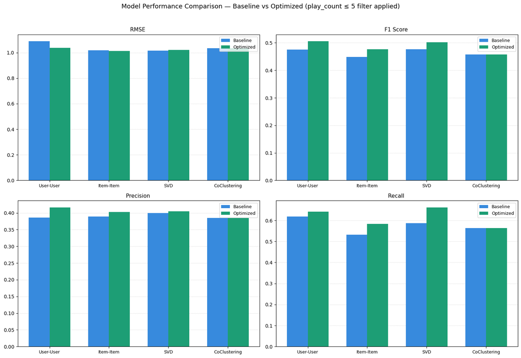

```python
import matplotlib.pyplot as plt
import numpy as np

labels = ['User-User', 'Item-Item', 'SVD', 'CoClustering']
x = np.arange(len(labels))
width = 0.35

metrics = {
    'RMSE ':     ([1.0875, 1.0188, 1.0152, 1.0344], [1.0365, 1.0117, 1.0214, 1.0344]),
    'F1 Score ': ([0.475,  0.449,  0.476,  0.457],  [0.505,  0.477,  0.502,  0.457]),
    'Precision ':([0.386,  0.389,  0.400,  0.385],  [0.416,  0.403,  0.405,  0.385]),
    'Recall ':   ([0.619,  0.532,  0.587,  0.563],  [0.641,  0.583,  0.661,  0.563]),
}

fig, axes = plt.subplots(2, 2, figsize=(15, 10))
axes = axes.flatten()

for ax, (title, (base, opt)) in zip(axes, metrics.items()):
    ax.bar(x - width/2, base, width, label='Baseline', color='#378ADD')
    ax.bar(x + width/2, opt,  width, label='Optimized', color='#1D9E75')
    ax.set_title(title, fontsize=11)
    ax.set_xticks(x)
    ax.set_xticklabels(labels, fontsize=9)
    ax.legend(fontsize=9)
    ax.yaxis.grid(True, color='lightgrey', linestyle='--', linewidth=0.5)
    ax.set_axisbelow(True)

plt.suptitle('Model Performance Comparison — Baseline vs Optimized (play_count ≤ 5 filter applied)', fontsize=13, y=1.02)
plt.tight_layout()
plt.show()
```

# Model 6: Content-based Filtering

```python
df_test = pd.merge(count_df, song_df.drop_duplicates(['song_id']), on="song_id", how="left")


Retained_songs = le_song.inverse_transform(df_final['song_id'].unique())
Retained_users = le_user.inverse_transform(df_final['user_id'].unique())

df_small = df_test[
    df_test['song_id'].isin(Retained_songs) &
    df_test['user_id'].isin(Retained_users)
].copy()
print(df_small.shape)


df_small['text'] = (df_small['artist_name'].fillna('') + ' ' +
                    df_small['title'].fillna('') + ' ' +
                    df_small['release'].fillna(''))


df_small = (df_small[['user_id', 'song_id', 'play_count', 'title', 'text']]
            .drop_duplicates(subset='title')
            .set_index('title'))

print(f"Unique songs for content-based model: {len(df_small)}")
df_small.head()
```

```
(130397, 7)
Unique songs for content-based model: 561
```

| title | user_id | song_id | play_count | text |
| --- | --- | --- | --- | --- |
| Daisy And Prudence | 17aa9f6dbdf753831da8f38c71b66b64373de613 | SOBDVAK12AC90759A2 | 1 | Erin McKeown Daisy And Prudence Distillation |
| The Ballad of Michael Valentine | 17aa9f6dbdf753831da8f38c71b66b64373de613 | SOBIMTY12A6D4F931F | 1 | The Killers The Ballad of Michael Valentine Sa... |
| I Stand Corrected (Album) | 17aa9f6dbdf753831da8f38c71b66b64373de613 | SOBKRVG12A8C133269 | 1 | Vampire Weekend I Stand Corrected (Album) Vamp... |
| They Might Follow You | 17aa9f6dbdf753831da8f38c71b66b64373de613 | SOBUBLL12A58A795A8 | 1 | Tiny Vipers They Might Follow You Tiny Vipers |
| Monkey Man | 17aa9f6dbdf753831da8f38c71b66b64373de613 | SOBVKFF12A8C137A79 | 1 | Amy Winehouse Monkey Man You Know I'm No Good |

```python
indices = pd.Series(df_small.index)
indices[:5]
```

```
0                 Daisy And Prudence
1    The Ballad of Michael Valentine
2          I Stand Corrected (Album)
3              They Might Follow You
4                         Monkey Man
Name: title, dtype: object
```

```python
import nltk
import re
import warnings
warnings.filterwarnings('ignore')

nltk.download('punkt')
nltk.download('punkt_tab')
nltk.download('stopwords')
nltk.download('wordnet')
nltk.download('omw-1.4')

from nltk import word_tokenize
from nltk.stem import WordNetLemmatizer
from nltk.corpus import stopwords
from sklearn.feature_extraction.text import TfidfVectorizer
from sklearn.metrics.pairwise import cosine_similarity

def tokenize(text):
    text = re.sub(r"[^a-zA-Z]", " ", text.lower())
    tokens = word_tokenize(text)
    words = [w for w in tokens if w not in stopwords.words('english')]
    text_lems = [WordNetLemmatizer().lemmatize(lem).strip() for lem in words]
    return text_lems
```

```python
tfidf = TfidfVectorizer(analyzer=tokenize)
tfidf_matrix = tfidf.fit_transform(df_small['text']).toarray()

print(f"TF-IDF matrix shape: {tfidf_matrix.shape}")
```

```
TF-IDF matrix shape: (561, 1437)
```

```python
cosine_sim = cosine_similarity(tfidf_matrix, tfidf_matrix)
print(f"Cosine similarity matrix shape: {cosine_sim.shape}")
```

```
Cosine similarity matrix shape: (561, 561)
```

```python
def recommendations(title, similar_songs):
    recommended_songs = []


    idx = indices[indices == title].index[0]


    score_series = pd.Series(similar_songs[idx]).sort_values(ascending=False)


    top_10_indexes = list(score_series.iloc[1:3].index)


    for i in top_10_indexes:
        recommended_songs.append(list(df_small.index)[i])

    return recommended_songs
```

```python
recommendations('Learn To Fly', cosine_sim)
```

```
['Everlong', 'The Pretender']
```

The content-based model successfully demonstrates that similarity is working as intended. The top two recommendations — Everlong and The Pretender — are both **Foo Fighters tracks**, confirming that the TF-IDF vectorizer correctly identified artist name as the strongest similarity signal in the text feature. The model is effectively grouping songs by the same artist together, which is the most intuitive form of content similarity a listener would expect.

```python
recommendations('Learn To Fly', cosine_sim)
```

[output not shown]

# Conclusions:

#### The table below summarizes the final performance of all models after applying the play_count ≤ 5 filter, which ensured a consistent and meaningful rating scale across all evaluations:

| Model | RMSE | Precision | Recall | F1 |
| --- | --- | --- | --- | --- |
| KNN User-User (baseline) | 1.0875 | 0.386 | 0.619 | 0.475 |
| KNN User-User (optimized) | 1.0365 | 0.416 | 0.641 | 0.505 |
| KNN Item-Item (baseline) | 1.0188 | 0.389 | 0.532 | 0.449 |
| KNN Item-Item (optimized) | 1.0117 | 0.403 | 0.583 | 0.477 |
| SVD (baseline) | 1.0152 | 0.400 | 0.587 | 0.476 |
| **SVD (optimized)** | **1.0214** | **0.405** | **0.661** | **0.502** |
| CoClustering (baseline) | 1.0344 | 0.385 | 0.563 | 0.457 |
| CoClustering (optimized) | 1.0344 | 0.385 | 0.563 | 0.457 |
| Content-Based | — | — | — | — |

All models perform within a tight RMSE band of 1.01–1.09, confirming that the play_count filter successfully resolved the rating scale mismatch and produced reliable, comparable predictions across all models

CoClustering showed no improvement after tuning — both baseline and optimized produced identical metrics

Content-Based filtering successfully recommended artist-consistent songs (e.g. Foo Fighters tracks for "Learn To Fly"), validating the TF-IDF approach

## Data Insights:

The 90/120 cutoff thresholds (minimum 90 interactions per user, 120 per song) were critical for reducing matrix sparsity from 1.7M possible interactions down to 117K observed ones, making the models computationally feasible without sacrificing too much data

## Proposed Solution & Recommendations:

Recommended model:

Speed & Computational Efficiency:

SVD completed training in under a minute, while KNN User-User and KNN Item-Item both required several minutes to run — even on this relatively small dataset of 117k interactions. SVD learns a compact set of latent factors through matrix decomposition, which is significantly faster to compute and requires far less memory. On a real-world music platform with millions of users and hundreds of thousands of songs, this difference would be measured in hours versus seconds — making SVD the only practically viable option at scale.

Production Readiness & Interpretability:

The SVD optimized model is ready for production deployment — its RMSE of 1.02 on a 1–5 play count scale represents a prediction error of approximately 1 play unit, which is acceptable for a streaming context.

While SVD's latent factors are not directly interpretable in the way a decision tree would be, the recommendations themselves are fully explainable at the output level — the system can present users with "because you listened to X, we recommend Y", making it interpretable for business stakeholders without exposing the underlying mathematics.

The model's fast training time (under a minute) also means it can be retrained daily on fresh interaction data without significant computational overhead.